# Likelihood Ratio Tests

## Likelihoods and model comparison

We have maximized likelihoods for single models

Now maximize likelihoods for competing models

- How to explicitly compare likelihoods?

## Likelihood ratio tests

- Nested models
  - Mean only
  - Mean for each group
- Asymptotic assumptions
- \(\chi^2\) distribution

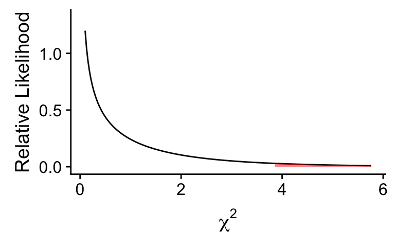

## Energy expenditure in naked mole rats

[figure not shown]

## Energy expenditure in naked mole rats

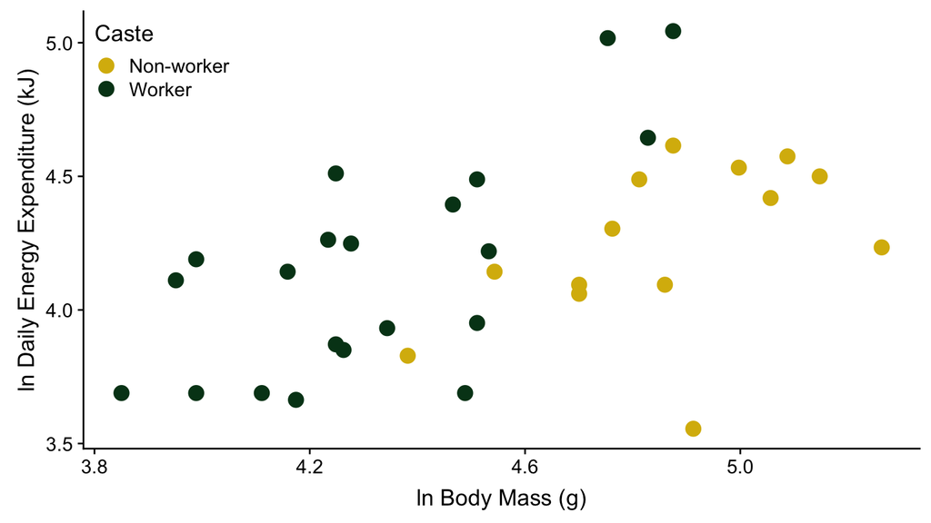

## Fit different models to these data

1. Mean (overall mean, no body mass)
2. ANOVA (group mean, no body mass)
3. OLS regression (body mass only, no grouping)
4. ANCOVA, intercepts varying
5. ANCOVA, slopes varying & intercepts varying

## 1: Mean

```r
fm1 <- lm(Energy ~ 1, data = M)
```

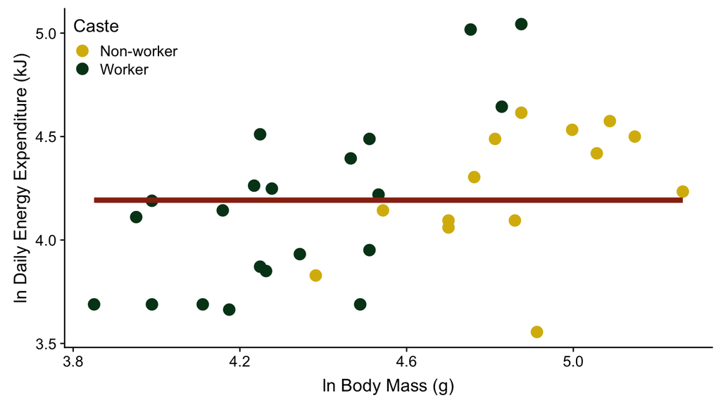

## 2: ANOVA

```r
fm2 <- lm(Energy ~ Caste, data = M)
```

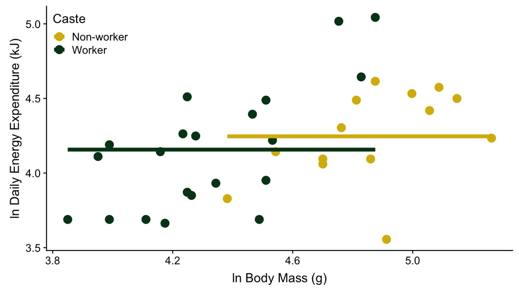

## 3: OLS regression

```r
fm3 <- lm(Energy ~ Mass, data = M)
```

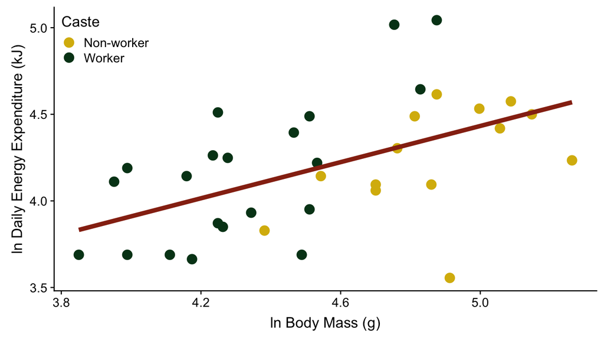

## 4: ANCOVA, intercepts varying

```r
fm4 <- lm(Energy ~ Mass + Caste, data = M)
```

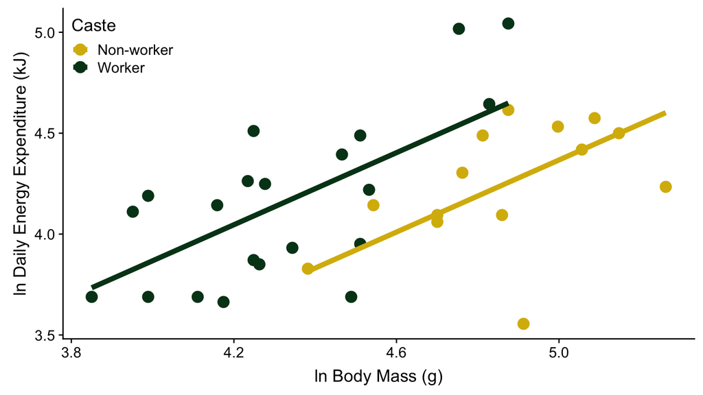

## 5: ANCOVA, intercepts and slopes vary

```r
fm5 <- lm(Energy ~ Mass * Caste, data = M)
```

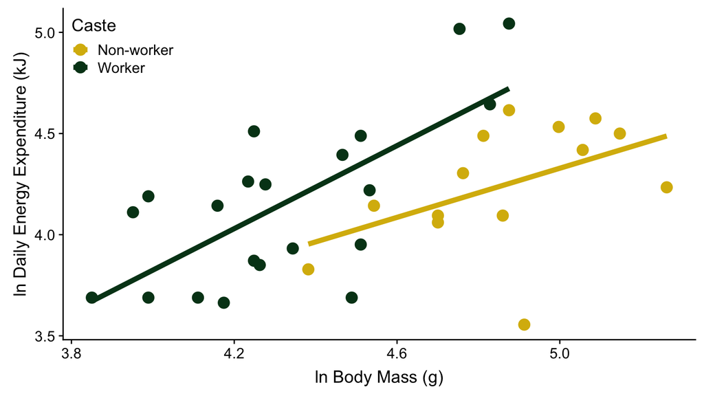

## 5: ANCOVA, intercepts and slopes varying

```r
summary(fm5)
```

```
##
## Call:
## lm(formula = Energy ~ Mass * Caste, data = M)
##
## Residuals:
##      Min       1Q   Median       3Q      Max
## -0.72004 -0.17990  0.05631  0.19551  0.43128
##
## Coefficients:
##                  Estimate Std. Error t value Pr(>|t|)
## (Intercept)        1.2939     1.6691   0.775   0.4441
## Mass               0.6069     0.3428   1.771   0.0865 .
## CasteWorker       -1.5713     1.9518  -0.805   0.4269
## Mass:CasteWorker   0.4186     0.4147   1.009   0.3206
## ---
## Signif. codes:  0 '***' 0.001 '**' 0.01 '*' 0.05 '.' 0.1 ' ' 1
##
## Residual standard error: 0.2965 on 31 degrees of freedom
## Multiple R-squared:  0.4278, Adjusted R-squared:  0.3725
## F-statistic: 7.727 on 3 and 31 DF,  p-value: 0.0005391
```

## Comparing likelihoods

| Model | *n* Estimated Parameters | log-Likelihood |
| --- | --- | --- |
| 1 - Mean only | 1 | -14.758 |
| 2 - ANOVA | 2 | -14.512 |
| 3 - OLS regression | 2 | -9.126 |
| 4 - ANCOVA, intercept only | 3 | -5.553 |
| 5 - ANCOVA, slope & intercept | 4 | -4.987 |

## Adding predictors *can’t decrease* model likelihood

At worst, likelihood will be equal. It will probably go up.

Add a column of [0, 1] random numbers:

```r
set.seed(341)
M <- M %>% mutate(Noise = runif(nrow(M), 0, 1))
```

```
##       Mass  Caste   Energy      Noise
## 1 3.850148 Worker 3.688879 0.14465769
## 2 3.988984 Worker 3.688879 0.89971270
## 3 4.110874 Worker 3.688879 0.37911477
## 4 4.174387 Worker 3.663562 0.05195667
## 5 4.248495 Worker 3.871201 0.80683672
## 6 4.262680 Worker 3.850148 0.76456540
```

## 6: ANCOVA 5 + Noise

```r
fm6 <- lm(Energy ~ Mass * Caste + Noise, data = M)
summary(fm6)
```

```
##
## Call:
## lm(formula = Energy ~ Mass * Caste + Noise, data = M)
##
## Residuals:
##      Min       1Q   Median       3Q      Max
## -0.70451 -0.18296  0.03892  0.19766  0.43246
##
## Coefficients:
##                  Estimate Std. Error t value Pr(>|t|)
## (Intercept)        1.5719     1.7346   0.906    0.372
## Mass               0.5602     0.3528   1.588    0.123
## CasteWorker       -1.8784     2.0222  -0.929    0.360
## Noise             -0.1083     0.1618  -0.669    0.508
## Mass:CasteWorker   0.4841     0.4298   1.127    0.269
##
## Residual standard error: 0.2992 on 30 degrees of freedom
## Multiple R-squared:  0.4363, Adjusted R-squared:  0.3611
## F-statistic: 5.804 on 4 and 30 DF,  p-value: 0.001392
```

## Comparing likelihoods

| Model | *n* Parameters | log-Likelihood |
| --- | --- | --- |
| 1 - Mean only | 1 | -14.758 |
| 2 - ANOVA | 2 | -14.512 |
| 3 - OLS regression | 2 | -9.126 |
| 4 - ANCOVA, intercept | 3 | -5.553 |
| 5 - ANCOVA, intercept, slope | 4 | -4.987 |
| 6 - ANCOVA, intercept, slope, Noise | 5 | -4.728 |

## Comparing models

Six nested models:

1. Mean
2. ANOVA
3. OLS regression
4. ANCOVA, intercepts varying
5. ANCOVA, intercepts and slopes varying
6. ANCOVA, intercepts and slopes varying, Noise

What one(s) has/have the best support?

## Likelihood ratio tests

- Compare *nested* models
  - Add or remove predictors
  - Add or remove interactions
  - **Outcome variable does not change**
- 2 * \(\Delta\)log-Likelihood of the two models
- Distributed as \(\chi^2\) with *df* equal to difference in number of estimated parameters
  - 1 more predictor, 1 less *df*

## ANOVA vs. Mean only

```r
(chisq <- as.numeric(2 * (logLik(fm2) - logLik(fm1))))
```

```
## [1] 0.4925981
```

```r
pchisq(chisq, df = 1, lower.tail = FALSE)
```

```
## [1] 0.4827707
```

```r
library(lmtest)
lrtest(fm1, fm2)
```

```
## Likelihood ratio test
##
## Model 1: Energy ~ 1
## Model 2: Energy ~ Caste
##   #Df  LogLik Df  Chisq Pr(>Chisq)
## 1   2 -14.758
## 2   3 -14.512  1 0.4926     0.4828
```

## Likelihood ratio tests

Compare sets of *nested* models. Each compared to the one above with a \(\chi^2\) test.

```r
lrtest(fm1, fm2, fm3, fm4, fm5, fm6)
```

```
## Likelihood ratio test
##
## Model 1: Energy ~ 1
## Model 2: Energy ~ Caste
## Model 3: Energy ~ Mass
## Model 4: Energy ~ Mass + Caste
## Model 5: Energy ~ Mass * Caste
## Model 6: Energy ~ Mass * Caste + Noise
##   #Df   LogLik Df   Chisq Pr(>Chisq)
## 1   2 -14.7581
## 2   3 -14.5118  1  0.4926   0.482771
## 3   3  -9.1258  0 10.7720  < 2.2e-16 ***
## 4   4  -5.5530  1  7.1456   0.007515 **
## 5   5  -4.9871  1  1.1318   0.287392
## 6   6  -4.7276  1  0.5190   0.471270
## ---
## Signif. codes:  0 '***' 0.001 '**' 0.01 '*' 0.05 '.' 0.1 ' ' 1
```

`Energy ~ Mass + Caste` is not improved by adding an interaction term.

## “Preferred” model

The “preferred” model is the one that is not improved by increased complexity. Interpretations based on this model:

```
##
## Call:
## lm(formula = Energy ~ Mass + Caste, data = M)
##
## Residuals:
##      Min       1Q   Median       3Q      Max
## -0.73388 -0.19371  0.01317  0.17578  0.47673
##
## Coefficients:
##             Estimate Std. Error t value Pr(>|t|)
## (Intercept) -0.09687    0.94230  -0.103   0.9188
## Mass         0.89282    0.19303   4.625 5.89e-05 ***
## CasteWorker  0.39334    0.14611   2.692   0.0112 *
## ---
## Signif. codes:  0 '***' 0.001 '**' 0.01 '*' 0.05 '.' 0.1 ' ' 1
##
## Residual standard error: 0.2966 on 32 degrees of freedom
## Multiple R-squared:  0.409,  Adjusted R-squared:  0.3721
## F-statistic: 11.07 on 2 and 32 DF,  p-value: 0.0002213
```

## “Preferred” model

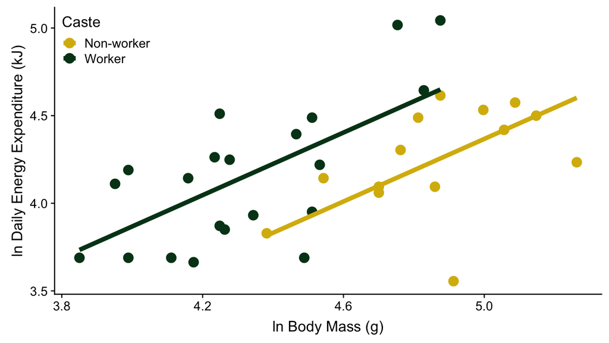

## Quiz 09-2

Lecture 09-3